# Iris_test

Marc XU

1 février 2019

```r
setwd("./../Marc")
getwd()
```

```
## [1] "/Users/marc/Desktop/Cours L3 S6/Stage/stageL3_2018-master/Marc/xx.Rproj/stageL3_2018/Marc"
```

# 1 Les iris de FISHER

```r
data(iris)
colnames(iris)
```

```
## [1] "Sepal.Length" "Sepal.Width"  "Petal.Length" "Petal.Width"
## [5] "Species"
```

```r
relation <- rep(1:3, each = 50)
iris <- data.frame(iris, relation)
iris$relation = as.factor(iris$relation)
# str(iris)
```

Il y a 4 études que nous devons réalisé, la longueur et la largeur de la sépale et du pétale (2 paramètres pour chacune des composantes de la corelle d’une fleur).

**Question : est-ce que le paramètre et la composante choisit diffère-t-il selon les espèces ?**

## 1.1 Descriptions de l’étude

Population : “Iris”  
Échantillon : n = 3 variétés d’iris => ni = 50  
Unité statistique : “Une iris”  
Expérience aléatoire : “Mesure sur les Iris”  
Variable aléatoire : “Largeur et longueur du sépale ou du pétale” => VA quantitative continue

Facteur stimulant à 3 modalités principal, fixe.  
HO : μset = μvir = μver ou H1 : un des μ est différent ==> ANOVA

Pour chacun des études, nous vérifier les conditions d’applications et ainsi utiliser le test adéquat (paramétrique ou non) pour pouvoir conclure.

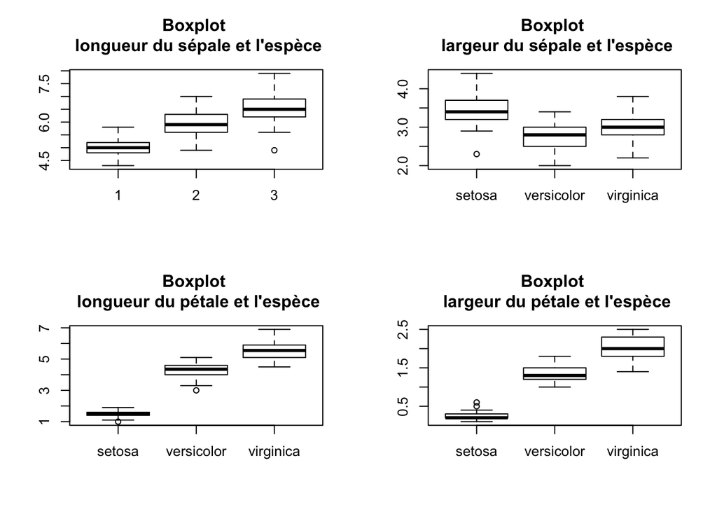

```r
par(mfrow = c(2, 2))
boxplot(iris$Sepal.Length ~ iris$relation,
        main = paste("Boxplot", "\n",
                     sub = "longueur du sépale et l'espèce"))
boxplot(iris$Sepal.Width ~ iris$Species,
        main = paste("Boxplot", "\n",
                     sub = "largeur du sépale et l'espèce"))
boxplot(iris$Petal.Length ~ iris$Species,
        main = paste("Boxplot", "\n",
                     sub = "longueur du pétale et l'espèce"))
boxplot(iris$Petal.Width ~ iris$Species,
        main = paste("Boxplot", "\n",
                     sub = "largeur du pétale et l'espèce"))
```

## 1.2 Conditions d’applications

### 1.2.1 Test de la normalité

**Hypothèse HO** : X suit une loi normale.  
**Hypothèse H1** : X ne suit pas une loi normale.

Pour vérifier la normalité, on utilise un test de Shapiro.

#### 1.2.1.1 Test pour la longueur du sépale

```r
shapi1 = by(iris$Sepal.Length, iris$relation, shapiro.test)
shapi1
```

```
## iris$relation: 1
##
##  Shapiro-Wilk normality test
##
## data:  dd[x, ]
## W = 0.9777, p-value = 0.4595
##
## --------------------------------------------------------
## iris$relation: 2
##
##  Shapiro-Wilk normality test
##
## data:  dd[x, ]
## W = 0.97784, p-value = 0.4647
##
## --------------------------------------------------------
## iris$relation: 3
##
##  Shapiro-Wilk normality test
##
## data:  dd[x, ]
## W = 0.97118, p-value = 0.2583
```

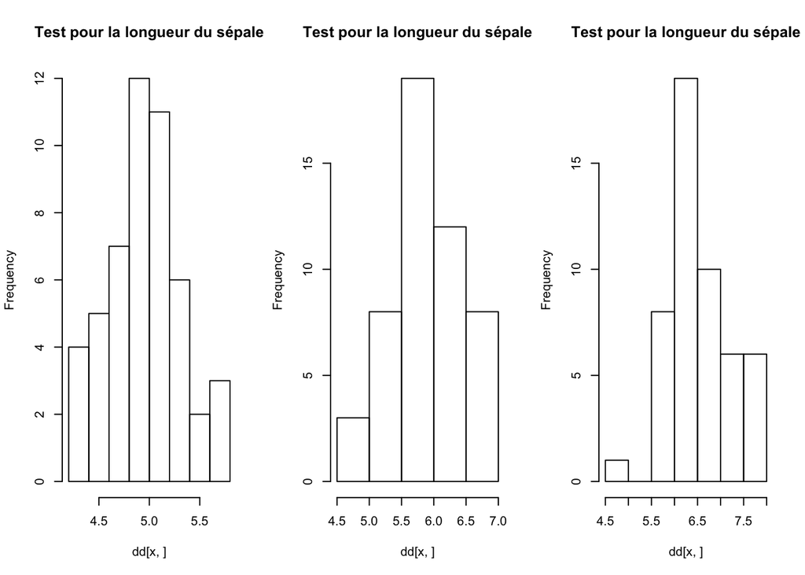

```r
par(mfrow= c(1, 3))
shapi1_hist = by(iris$Sepal.Length, iris$relation, hist,
                 main = "Test pour la longueur du sépale")
```

#### 1.2.1.2 Test pour la largeur du sépale

```r
shapi2 = by (iris$Sepal.Width, iris$relation, shapiro.test)
shapi2
```

```
## iris$relation: 1
##
##  Shapiro-Wilk normality test
##
## data:  dd[x, ]
## W = 0.97172, p-value = 0.2715
##
## --------------------------------------------------------
## iris$relation: 2
##
##  Shapiro-Wilk normality test
##
## data:  dd[x, ]
## W = 0.97413, p-value = 0.338
##
## --------------------------------------------------------
## iris$relation: 3
##
##  Shapiro-Wilk normality test
##
## data:  dd[x, ]
## W = 0.96739, p-value = 0.1809
```

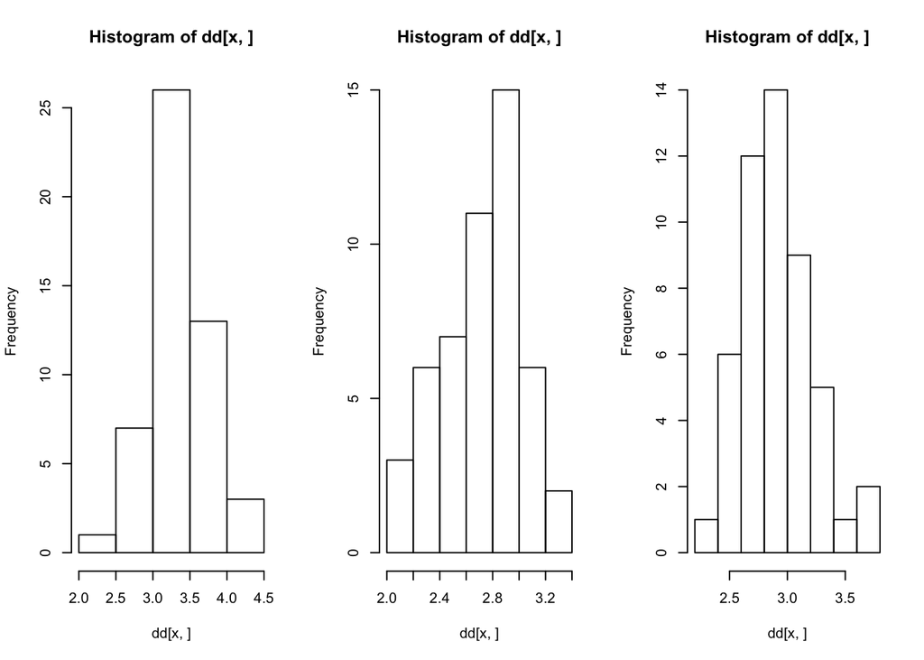

```r
par(mfrow= c(1, 3))
shapi2_hist = by(iris$Sepal.Width, iris$relation, hist)
```

#### 1.2.1.3 Test pour la longueur du pétale

```r
shapi3 = by(iris$Petal.Length, iris$relation, shapiro.test)
shapi3
```

```
## iris$relation: 1
##
##  Shapiro-Wilk normality test
##
## data:  dd[x, ]
## W = 0.95498, p-value = 0.05481
##
## --------------------------------------------------------
## iris$relation: 2
##
##  Shapiro-Wilk normality test
##
## data:  dd[x, ]
## W = 0.966, p-value = 0.1585
##
## --------------------------------------------------------
## iris$relation: 3
##
##  Shapiro-Wilk normality test
##
## data:  dd[x, ]
## W = 0.96219, p-value = 0.1098
```

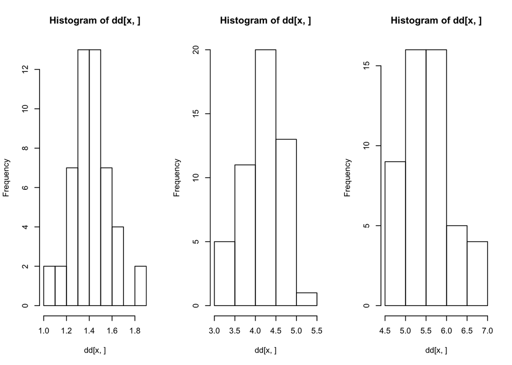

```r
par(mfrow= c(1, 3))
shapi3_hist = by(iris$Petal.Length, iris$relation, hist)
```

#### 1.2.1.4 Test pour la largeur du pétale

```r
shapi4 = by (iris$Petal.Width, iris$relation, shapiro.test)
shapi4
```

```
## iris$relation: 1
##
##  Shapiro-Wilk normality test
##
## data:  dd[x, ]
## W = 0.79976, p-value = 8.659e-07
##
## --------------------------------------------------------
## iris$relation: 2
##
##  Shapiro-Wilk normality test
##
## data:  dd[x, ]
## W = 0.94763, p-value = 0.02728
##
## --------------------------------------------------------
## iris$relation: 3
##
##  Shapiro-Wilk normality test
##
## data:  dd[x, ]
## W = 0.95977, p-value = 0.08695
```

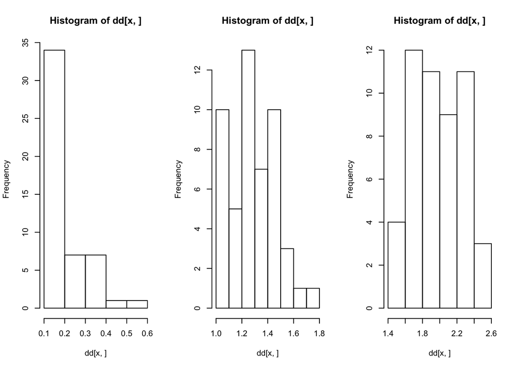

```r
par(mfrow= c(1, 3))
shapi4_hist = by(iris$Petal.Width, iris$relation, hist)
```

Sur les 4 test sur la normalité, on mesure 3 modalités à la fois :

L’histogramme confirme le résultat.

**Conclusion sur les CA** : Seule la “largeur du pétale” ne suit pas une loi normale. Il n’y aura pas besoin de vérifier l’homoscédasticité (égalité des variances) de la “largeur du pétale”.

### 1.2.2 Test d’homogéneité des variances

**Hypothèse H0** : Il y a égalité des 3 variances : σ²set = σ²ver = σ²vir  
**Hypothèse H1** : Il n’y a pas égalité des variances

Pour vérifier l’égalité des variances, nous utilisons le test de Bartlett.

#### 1.2.2.1 Test pour la longueur du sépale

```r
bart1 = bartlett.test(Sepal.Length ~ Species, data = iris)
bart1$p.value
```

```
## [1] 0.0003345076
```

#### 1.2.2.2 Test pour la largeur du sépale

```r
bart2 = bartlett.test(Sepal.Width ~ Species, data = iris)
bart2$p.value
```

```
## [1] 0.3515028
```

#### 1.2.2.3 Test pour la longueur du pétale

```r
bart3 = bartlett.test(Petal.Length ~ Species, data = iris)
bart3$p.value
```

```
## [1] 9.229038e-13
```

La largeur du sépale a une p.value supérieur à 0.05, donc le test est non significatif, on ne rejette pas HO. Il y a égalité des variances.

## 1.3 Test paramétrique

### 1.3.1 Largeur du sépale

Nous allons réaliser un test d’ANOVA (aov)

```r
test_anova = aov(Sepal.Width ~ relation, data = iris)
summary(test_anova)
```

```
##              Df Sum Sq Mean Sq F value Pr(>F)
## relation      2  11.35   5.672   49.16 <2e-16 ***
## Residuals   147  16.96   0.115
## ---
## Signif. codes:  0 '***' 0.001 '**' 0.01 '*' 0.05 '.' 0.1 ' ' 1
```

Fcal > Ftheo.  
**Conclusion** : au risque α = 5%, le test est significatif, on rejette donc H0. La largeur du sépale est différente selon l’espèce.

Il y a au moins une des 3 moyennes est différente.  
Nous allons réaliser un test post-hoc pour déterminer quelle(s) moyenne(s) diffère-t-il des autres.

```r
TukeyHSD(test_anova)
```

```
##   Tukey multiple comparisons of means
##     95% family-wise confidence level
##
## Fit: aov(formula = Sepal.Width ~ relation, data = iris)
##
## $relation
##       diff         lwr        upr     p adj
## 2-1 -0.658 -0.81885528 -0.4971447 0.0000000
## 3-1 -0.454 -0.61485528 -0.2931447 0.0000000
## 3-2  0.204  0.04314472  0.3648553 0.0087802
```

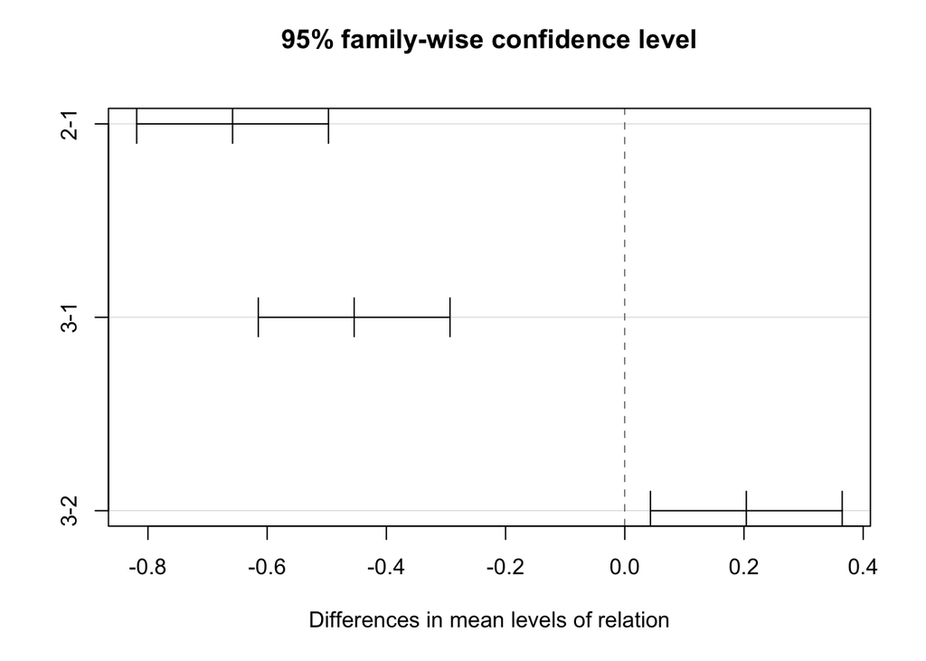

```r
plot(TukeyHSD(test_anova))
```

Si l’intervalle de confiance de la différence des moyennes passe par 0, alors il y a égalité des moyennes.  
Cependant, aucune des intervalles ne passent par 0, donc chez les 3 espèces, les sépales n’ont pas la même largeur.

## 1.4 Test non paramétrique

### 1.4.1 Longueur du sépale chez les 3 espèces

```r
long_sep = kruskal.test(Sepal.Length ~ relation, data = iris)
long_sep$p.value
```

```
## [1] 8.918734e-22
```

**Conclusion** : la p.value < 5%, le test est significatif, on rejette H0. La longueur du sépale est différente selon l’espèce.

Il y a au moins une des 3 moyennes est différente.  
Nous allons réaliser un test post-hoc pour déterminer quelle(s) moyenne(s) diffère-t-il des autres.

```r
pairwise.wilcox.test(iris$Sepal.Length, iris$relation, p.adjust = "bonferroni")
```

```
##
##  Pairwise comparisons using Wilcoxon rank sum test
##
## data:  iris$Sepal.Length and iris$relation
##
##   1       2
## 2 2.5e-13 -
## 3 < 2e-16 1.8e-06
##
## P value adjustment method: bonferroni
```

**Conclusion** :  
μset - μvir < 2% = significativement différent  
μvir - μver < 2% = significativement différent  
μver - μset < 2% = significativement différent  
Donc toutes les moyennes sur la longueur du sépale sont significativement différentes selon l’espèce.

### 1.4.2 Longueur du pétale chez les 3 espèces

```r
long_pet = kruskal.test(Petal.Length ~ relation, data = iris)
long_pet$p.value
```

```
## [1] 4.803974e-29
```

**Conclusion** : la p.value < 5%, le test est significatif, on rejette H0. La longueur du pétale est différente selon l’espèce.

Il y a au moins une des 3 moyennes est différente.  
Nous allons réaliser un test post-hoc pour déterminer quelle(s) moyenne(s) diffère-t-il des autres.

```r
pairwise.wilcox.test(iris$Petal.Length, iris$relation, p.adjust = "non")
```

```
##
##  Pairwise comparisons using Wilcoxon rank sum test
##
## data:  iris$Petal.Length and iris$relation
##
##   1      2
## 2 <2e-16 -
## 3 <2e-16 <2e-16
##
## P value adjustment method: none
```

```r
pairwise.wilcox.test(iris$Petal.Length, iris$relation, p.adjust = "bonferroni")
```

```
##
##  Pairwise comparisons using Wilcoxon rank sum test
##
## data:  iris$Petal.Length and iris$relation
##
##   1       2
## 2 < 2e-16 -
## 3 < 2e-16 2.7e-16
##
## P value adjustment method: bonferroni
```

**Conclusion** :  
μset - μvir < 2% = significativement différent  
μvir - μver < 2% = significativement différent  
μver - μset < 2% = significativement différent  
Donc toutes les moyennes sur la longueur du pétale sont significativement différentes selon l’espèce.

### 1.4.3 Largeur du pétale chez les 3 espèces

```r
larg_pet = kruskal.test(Petal.Width ~ relation, data = iris)
larg_pet$p.value
```

```
## [1] 3.261796e-29
```

**Conclusion** : la p.value < 5%, le test est significatif, on rejette H0. La largeur du pétale est différente selon l’espèce.

Il y a au moins une des 3 moyennes est différente.  
Nous allons réaliser un test post-hoc pour déterminer quelle(s) moyenne(s) diffère-t-il des autres.

```r
pairwise.wilcox.test(iris$Petal.Width, iris$relation, p.adjust = "bonferroni")
```

```
##
##  Pairwise comparisons using Wilcoxon rank sum test
##
## data:  iris$Petal.Width and iris$relation
##
##   1       2
## 2 < 2e-16 -
## 3 < 2e-16 2.9e-16
##
## P value adjustment method: bonferroni
```

**Conclusion** :  
μset - μvir < 2% = significativement différent  
μvir - μver < 2% = significativement différent  
μver - μset < 2% = significativement différent  
Donc toutes les moyennes sur la largeur du pétale sont significativement différentes selon l’espèce.